# Tarea 5. Expresión diferencial con datos RNA-Seq

Roxana Andreea Moldovan Moldovan

2022-06-11

# 1. Introducción

En esta tarea llevaremos a cabo un análisis de la expresión diferencial a partir de los datos de la **Tarea 3** [PRJNA821482](https://www.ncbi.nlm.nih.gov/bioproject/821482).

En este estudio se analiza el patrón de expresión génica mediante RNA-seq de 12 muestras correspondientes a la exposición a **Normoxia** e **Hipoxia** de dos líneas celulares (**HSC** y **K562**) por triplicado.

# 2. Carga de datos

## Paquetes empleados:

```r
pacman::p_load(edgeR,SummarizedExperiment, ggplot2, pbapply, limma,
               DESeq2, ReportingTools)
```

## Carga de datos del experimento.

```r
datos="PRJNA821482.rda"
load(paste(dir_datos, datos, sep=""))
```

# 3. Analisis de expresión diferencial.

## 3.1 edgeR clásico

```r
# Datos fenotípicos de la primera muestra:
colData(PRJNA821482)
```

```
## DataFrame with 12 rows and 5 columns
##                     Run     Muestra TipoCelular Tratamiento  BioProject
##             <character> <character>    <factor>    <factor> <character>
## SRR18537220 SRR18537220  GSM5984186         HSC    Hypoxia  PRJNA821482
## SRR18537221 SRR18537221  GSM5984185         HSC    Hypoxia  PRJNA821482
## SRR18537222 SRR18537222  GSM5984184         HSC    Hypoxia  PRJNA821482
## SRR18537223 SRR18537223  GSM5984183         HSC    Normoxia PRJNA821482
## SRR18537224 SRR18537224  GSM5984182         HSC    Normoxia PRJNA821482
## ...                 ...         ...         ...         ...         ...
## SRR18537227 SRR18537227  GSM5984179        K562    Hypoxia  PRJNA821482
## SRR18537228 SRR18537228  GSM5984178        K562    Hypoxia  PRJNA821482
## SRR18537229 SRR18537229  GSM5984177        K562    Normoxia PRJNA821482
## SRR18537230 SRR18537230  GSM5984176        K562    Normoxia PRJNA821482
## SRR18537231 SRR18537231  GSM5984175        K562    Normoxia PRJNA821482
```

Como hemos indicado anteriormente tenemos datos relativos de expresión bajo dos condiciones experimentales y dos líneas celulares distintas.  
Para este primer análisis nos centraremos en el efecto se la ausencia de oxígeno sobre la expresión, para ello tomaremos la variable fenotípica **Tratamiento** que presenta dos niveles:

- **Hypoxia** -> Crecimiento en ausencia de oxígeno.
- **Normoxia** -> Crecimiento en presencia de oxígeno.

### Estudio de los datos:

Construimos un objeto de tipo **DGEList**

```r
dge <- edgeR::DGEList(counts = assay(PRJNA821482),
               group = colData(PRJNA821482)$Tratamiento)
```

Describimos el tamaños de las librerías:

```r
summary(dge$samples[,"lib.size"])
```

```
##     Min.  1st Qu.   Median     Mean  3rd Qu.     Max.
##  7711465  8029019  8498422  8585716  8788620 10109450
```

¿Qué porcentaje de genes no presentan anotación?

```r
total = nrow(rowData(PRJNA821482))
# funcion que calcula el procentaje de genes no anotados:
porcent <- function(x, t){
  s = sum(is.na(x))
  paste0( s/t *100, "%")
}

paste0("Encontramos ", total, " genes, de estos no presentan anotación:")
```

```
## [1] "Encontramos 25189 genes, de estos no presentan anotación:"
```

```r
s <- sapply(rowData(PRJNA821482), porcent, total)
s
```

```
##               ALIAS            ENTREZID             ENSEMBL
##                "0%"                "0%" "9.20639961888126%"
```

El 9,2% de los genes no están atontados según ENSEMBL.

### Eliminación de filas con conteos bajos:

Debemos tener en cuenta que en algunos casos señales pequeñas pueden deberse al ruido y no a la verdadera expresión del gen.  
Por otro lado, incluso si de expresiones bajas se tratase, estas no nos ofrecen mucha información y no es fiable desde el punto de vista estadístico.  
Con el fin de solventarlo:  
* Determinamos los conteos por millón de cada gen para cada una de las muestras usando la función **cpm**.  
* Tomamos las que presentan un conteo mayor de 0,5. * Si tenemos en más de dos muestras conteos de más de 0,5 determinamos que el gen se expresa.

```r
# Conteos por millon:
c <- cpm(PRJNA821482)
mantener <- rowSums(c > 0,5) > 2
table(mantener)
```

```
## mantener
## FALSE  TRUE
##  6497 18692
```

Observamos que 6497 presentan expresiones muy bajas. Los eliminamos y recalculamos el tamaño de las librerías:

```r
dge <- dge[mantener, keep.lib.sizes=FALSE]
```

Describimos el tamaños de las librerías nuevamente:

```r
summary(dge$samples[,"lib.size"])
```

```
##     Min.  1st Qu.   Median     Mean  3rd Qu.     Max.
##  7711207  8028604  8498140  8585385  8788336 10109028
```

Lo representamos:

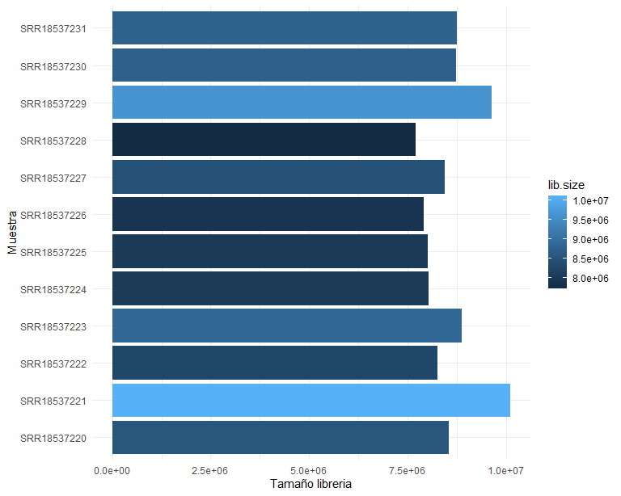

Fig1. Representación del tamaño de las librerias por muestra.

```r
ggplot2::ggplot(dge$samples, aes(y= lib.size, x =row.names(dge$samples),
                                 fill=lib.size)) +
                geom_col() + coord_flip() + theme_minimal() +
                xlab("Muestra") +  ylab("Tamaño libreria")
```

### Estimamos los parámetros de dispersión:

#### Parámetro de dispersión común para todos los genes:

Estimamos un solo parámetro de dispersión común para todos los genes.

```r
dge.c = edgeR::estimateCommonDisp(dge)
et.c = exactTest(dge.c)

paste0("La dispersión obtenida es ", dge.c$common.dispersion)
```

```
## [1] "La dispersión obtenida es 0.532404658953035"
```

Mostramos los más significativos:

```r
topTags(et.c, 2)
```

```
## Comparison of groups:  Normoxia-Hypoxia
##              logFC   logCPM       PValue          FDR
## MT1HL1   -6.836871 3.315645 8.269385e-16 1.545713e-11
## C6orf223 -5.833936 5.127945 2.903447e-14 2.713561e-10
```

Fijando un nivel de significación de 0.05, ¿Cuántos genes parecen mostrar expresión diferencial en función de su exposición a oxígeno?

```r
sum(et.c$table[,"PValue"]< 0.05)
```

```
## [1] 776
```

### Ajuste de los resultados obtenidos:

Hemos asumido una dispersión común para todos los genes, pero para poder interpretar los resultados debemos ajustar los p valores obtenidos, para ello empleamos el método de **Benjamini-Hochberg**.

```r
p_valores <- et.c$table[,"PValue"]
pv_ajust <- p.adjust(p_valores, "BH")
```

Fijando un FDR de 0.05, ¿Cuántos genes realmente presentan diferencias significativas en las medias de los conteos en función del tratamiento?

```r
sum(pv_ajust < 0.05)
```

```
## [1] 89
```

Como el enunciado nos indica hemos asumido una dispersión común, aunque en algunos casos, sobre todo si el tamaño de las librerías es grande esta asunción nos puede conducir a errores, por lo que repetimos el análisis calculando la dispersión por gen.

#### Parámetro de dispersión distinta para cada genes:

En este caso asumimos dispersión distinta para cada uno de los genes.

```r
dge.t = edgeR::estimateTagwiseDisp(dge.c)
et.t = exactTest(dge.t)
```

Mostramos los más significativos:

```r
topTags(et.t, 2)
```

```
## Comparison of groups:  Normoxia-Hypoxia
##              logFC   logCPM       PValue          FDR
## MIR210HG -4.306703 4.837212 1.593164e-19 2.977942e-15
## ALDOC    -2.708550 6.144788 2.753279e-15 2.573215e-11
```

Fijando un nivel de significación de 0.05 y asumiendo dispersiones distintas, ¿Cuántos genes parecen mostrar expresión diferencial en función de su exposición a oxígeno?

```r
sum(et.t$table[,"PValue"]< 0.05)
```

```
## [1] 514
```

### Ajuste de los resultados obtenidos:

Hemos asumido una dispersiones distintas para los genes, pero para poder interpretar los resultados debemos corregir los p valores obtenidos, para ello empleamos el método de **Benjamini-Hochberg**.

```r
p_valores_t <- et.t$table[,"PValue"]
pv_ajust_t <- p.adjust(p_valores_t, "BH")
```

Fijando un FDR de 0.05, ¿Cuántos genes realmente se expresan diferencialmente?

```r
sum(pv_ajust_t < 0.05)
```

```
## [1] 31
```

De esta forma, únicamente 31 genes presentan diferencias significativas en las medias de los conteos en función de la presencia de oxigeno en el medio.

### Combinación de resultados:

Con el fin de mostrar los resultados en un informe tomaremos los genes que presentan expresión diferencial en alguno de los test llevados a cabo con  
**edgeR** (asumiendo o no dispersión común de los genes), basandonos en los pvalores ajustados con el método de **Benjamini-Hochberg** con una FDR de 0.05.  
Como información tenemos:

- **ENTREZID** -> Identificadores ENTREZID
- **ENSEMBL** -> Identificadores ENSEMBL
- **Pval_Common** -> P valores obtenidos asumiendo dispersión común.
- **adj_Pval_Common** -> P valores ajustados asumiendo dispersión común.
- **Pval_Tagwise** -> P valores asumiendo dispersión distinta por gen.
- **adj_Pval_Tagwise** -> P valores ajustados asumiendo dispersión distinta.

```r
# Combinamos los datos
result <- cbind(rowData(PRJNA821482)[mantener, c("ENTREZID", "ENSEMBL")],
                Pval_Common = et.c$table[,"PValue"],
                adj_Pval_Common = pv_ajust,
                Pval_Tagwise = et.t$table[,"PValue"],
                adj_Pval_Tagwise = pv_ajust_t)

# Nos quedamos con los significativos:
sign <- (pv_ajust_t < 0.05 | pv_ajust < 0.05)
Dat_inf <-result[sign,]
```

### Generación de informe:

Tomamos un nivel de significación alfa de 0.05 y mostramos los resultados de los genes con expresión diferencial significativa en función del oxigeno en un informe:

```r
final_data = Dat_inf

entrezid = final_data$ENTREZID
ENTREZID= ifelse(is.na(entrezid), NA,
                 paste0("<a href='http://www.ncbi.nlm.nih.gov/gene/?term=",
                  entrezid,"'>",entrezid,"</a>"))


ensembl = final_data$ENSEMBL
ENSAMBL = ifelse(is.na(ensembl), NA,
                      paste0("<a href='http://www.ensembl.org/Macaca_mulatta",
                             "/Gene/Summary?db=core;g=",
                             ensembl ,"'>",ensembl,"</a>"))
```

```r
info = cbind(EntrezID = ENTREZID, Ensembl = ENSAMBL,
             final_data[,3:6],  stringsAsFactors = F )

f_out = "T5_edgeR_clasico.DE"
report_dir = "Reports/"
titulo = paste0("PRJNA821482"," : Analisis de expresion ",
                "diferencial (edgeR clasico).")

report1 = ReportingTools::HTMLReport(shortName = f_out, title = titulo,
                                     reportDirectory = report_dir)
publish(info,report1)
finish(report1)
```

```
## [1] "Reports//T5_edgeR_clasico.DE.html"
```

## 3.2 edgeR utilizando modelo lineal generalizado

En este apartado emplearemos todas las variables fenotípicas de las que disponemos para el análisis diferencial.  
En nuestro caso tomaremos **Tratamiento** que presenta dos niveles:

- **Hypoxia** -> Crecimiento en ausencia de oxígeno.
- **Normoxia** -> Crecimiento en presencia de oxígeno.

Y **TipoCelular** que presenta dos niveles:

- **HSC** -> Células madre hematopoyéticas.
- **K562** -> Linfoblastos de paciente con leucemia mieloide crónica.

Comprobamos que estas variables están en todas las muestras.

```r
which(is.na(colData(PRJNA821482)$TipoCelular))
```

```
## integer(0)
```

```r
which(is.na(colData(PRJNA821482)$Tratamiento))
```

```
## integer(0)
```

Construimos un objeto de tipo DGEList.

```r
dge2 <- edgeR::DGEList(counts = assay(PRJNA821482))
```

### Eliminación de filas con conteos bajos:

```r
# Nos quedamo con la que presnetaban conteos altos del apartado anterior:
dge2 <- dge2[mantener, keep.lib.sizes=FALSE]
```

### Matriz de diseño:

```r
# Tomamos las variables a estudiar.
tratamiento <- factor(colData(PRJNA821482)$Tratamiento)
tipo_celular <- factor(colData(PRJNA821482)$TipoCelular)

table(tratamiento, tipo_celular)
```

```
##            tipo_celular
## tratamiento HSC K562
##    Hypoxia    3    3
##    Normoxia   3    3
```

Tenemos 3 replicas para cada condición.

Construimos una variable que recoja la combinación de ambos factores.

```r
# Creamos una función que concatene y asigne los nombres:
concat <- function(x, t=tratamiento, tc=tipo_celular){ #Numero de fila
  a = paste(t[x], tc[x],sep="_")
  a
}

# Creamos la variable factor:
fac = lapply(list(1:ncol(PRJNA821482)), FUN=concat)
tt = factor(unlist(fac))
tt
```

```
##  [1] Hypoxia_HSC   Hypoxia_HSC   Hypoxia_HSC   Normoxia_HSC  Normoxia_HSC
##  [6] Normoxia_HSC  Hypoxia_K562  Hypoxia_K562  Hypoxia_K562  Normoxia_K562
## [11] Normoxia_K562 Normoxia_K562
## Levels: Hypoxia_HSC Hypoxia_K562 Normoxia_HSC Normoxia_K562
```

Creamos la matriz de diseño

```r
# Determinamos la matriz de diseño:
matriz <- model.matrix(~ 0 + tt)
colnames(matriz) <- levels(tt)
matriz
```

```
##    Hypoxia_HSC Hypoxia_K562 Normoxia_HSC Normoxia_K562
## 1            1            0            0             0
## 2            1            0            0             0
## 3            1            0            0             0
## 4            0            0            1             0
## 5            0            0            1             0
## 6            0            0            1             0
## 7            0            1            0             0
## 8            0            1            0             0
## 9            0            1            0             0
## 10           0            0            0             1
## 11           0            0            0             1
## 12           0            0            0             1
## attr(,"assign")
## [1] 1 1 1 1
## attr(,"contrasts")
## attr(,"contrasts")$tt
## [1] "contr.treatment"
```

### Estimación de las dispersiones

```r
dge2 = edgeR::estimateDisp(dge2, matriz)
```

Empleando la función **estimateDisp** estimamos las dispersiones mediante tres métodos:

- **Common dispersion** -> Dispersión común en todos los genes.

```r
dge2$common.dispersion
```

```
## [1] 0.004368064
```

- **Tag wise dispersion** -> Dispersión a nivel de gen.

```r
summary(dge2$tagwise.dispersion)
```

```
##     Min.  1st Qu.   Median     Mean  3rd Qu.     Max.
## 0.002324 0.003895 0.007392 0.039342 0.040962 0.557740
```

- **Trended dispersion** -> Estimación de la dispersión a nivel de genes con abundancia similar.

```r
summary(dge2$trended.dispersion)
```

```
##     Min.  1st Qu.   Median     Mean  3rd Qu.     Max.
## 0.003274 0.003980 0.007186 0.034640 0.042633 0.150463
```

A partir de los valores de dispersión, podemos calcular el coeficiente de la variación biológica (**BGV**) y representarlo gráficamente con la función **plotBCV** del paquete **edgeR**.

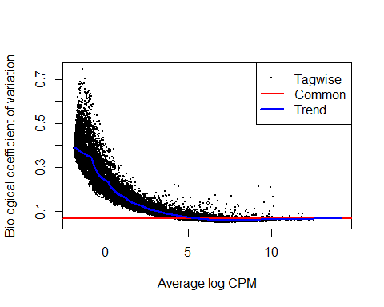

Fig2. Representación del coeficiente de variación biológico (BCV) frente a la abundancia de los genes.

```r
# Mostramos los resultados
edgeR::plotBCV(dge2)
```

### Ajuste de modelos lineales generalizados

```r
# Ajustamos los modelos lineales generalizados:
fit <- edgeR::glmFit(dge2, design=matriz)
# Influencia de las variables en los conteos:
lrt1 = edgeR::glmLRT(fit, coef=1:4)
topTags(lrt1)
```

```
## Coefficient:  Hypoxia_HSC Hypoxia_K562 Normoxia_HSC Normoxia_K562
##          logFC.Hypoxia_HSC logFC.Hypoxia_K562 logFC.Normoxia_HSC
## A1CF             -26.03345          -21.46273          -26.03345
## A3GALT2          -26.03345          -26.03345          -22.44317
## AACSP1           -26.03345          -18.70163          -26.03345
## AATK-AS1         -26.03345          -23.29651          -22.16404
## ABCA8            -26.03345          -18.92218          -26.03345
## ABCC11           -26.03345          -22.77500          -24.12257
## ABCG8            -26.03345          -24.09093          -23.32552
## ABLIM2           -26.03345          -23.28944          -22.14891
## ACTL8            -26.03345          -15.01399          -23.33051
## ACTR3BP5         -26.03345          -21.84720          -24.12242
##          logFC.Normoxia_K562      logCPM        LR PValue FDR
## A1CF               -22.00979 -1.43875469  3842.891      0   0
## A3GALT2            -26.03345 -1.87939414  4580.655      0   0
## AACSP1             -18.50838  0.56173493  6496.307      0   0
## AATK-AS1           -24.20990 -1.68685038  3169.041      0   0
## ABCA8              -19.67940  0.01447503  6116.986      0   0
## ABCC11             -21.80469 -1.55755575  3498.796      0   0
## ABCG8              -23.42859 -1.82879463  4099.429      0   0
## ABLIM2             -26.03345 -1.73251065  3675.925      0   0
## ACTL8              -15.32795  3.78273490 38886.830      0   0
## ACTR3BP5           -20.75421 -1.16342594  3451.567      0   0
```

En el apartado anterior hemos obtenido información acerca de como afecta el crecimiento la presencia y ausencia de oxigeno, ahora tenemos en cuenta además el tipo celular.

¿ Qué información nos gustaría obtener?

- **C_cel** -> Genes que se expresan diferentemente según el tipo celular, nos puede interesar que genes se expresan diferencialmente en las células leucémicas (**K562**) con respecto a las células madre (**HSC**).
- **C_HSC** -> Como afecta la hipoxia a la línea celular **HSC**.
- **C_K562** -> Como afecta la hipoxia a la línea celular **K562**.
- **C_total** -> Comparamos que genes se expresan diferencialmente en hipoxia en las células **K562**, con respecto a las **HSC**.

```r
contrast <- limma::makeContrasts( C_cel = (Normoxia_HSC + Hypoxia_HSC)
                                           - (Normoxia_K562 +Hypoxia_K562),
                                  C_HSC = Normoxia_HSC - Hypoxia_HSC,
                                  C_K562 = Normoxia_K562 - Hypoxia_K562,
                                  C_total = (Normoxia_HSC - Hypoxia_HSC)
                                        - (Normoxia_K562 - Hypoxia_K562),
                                  levels = matriz)
```

Ajustaremos todos los p valores obtenidos a través del método de **Benjamini-Hochberg**, y para determinar los genes que presentan expresión diferencial tomaremos un **FDR** de 0.05.  
Partiendo de esto:

**¿Cuántos y que genes presentan expresión diferencial en la línea celular** **K562 con respecto a la HSC?**

```r
lrt_cel = edgeR::glmLRT(fit, contrast = contrast[,"C_cel"])
p_ajust_cel = p.adjust(lrt_cel$table[,"PValue"])
sum(p_ajust_cel< 0.05)
```

```
## [1] 10504
```

```r
# Los más significativos son:
topTags(lrt_cel)
```

```
## Coefficient:  1*Hypoxia_HSC -1*Hypoxia_K562 1*Normoxia_HSC -1*Normoxia_K562
##            logFC    logCPM        LR PValue FDR
## MPO     34.64192 11.524100 15640.780      0   0
## NR2F2  -30.10632  7.970883  9211.185      0   0
## RHOXF2 -29.82780  7.835915  8764.951      0   0
## TPSAB1  29.59060  8.673160  8839.296      0   0
## TPSB2   29.55461  9.345617 10490.087      0   0
## S100A6  29.00513  8.382270  8761.126      0   0
## CD163   28.67236  8.175260  9688.034      0   0
## IRAK3   28.63541  7.250515  7107.169      0   0
## ELANE   28.11350  9.260799  9053.143      0   0
## MAGEA3 -27.90828  6.859076  6864.246      0   0
```

**¿Cuántos genes presentan expresión diferencial en células HSC tras la** **exposición a hipoxia con respecto a normoxia?**

```r
lrt_HSC = edgeR::glmLRT(fit, contrast = contrast[,"C_HSC"])
p_ajust_HSC = p.adjust(lrt_HSC$table[,"PValue"])
sum(p_ajust_HSC< 0.05)
```

```
## [1] 2881
```

```r
# Los más significativos son:
topTags(lrt_HSC)
```

```
## Coefficient:  -1*Hypoxia_HSC 1*Normoxia_HSC
##                  logFC   logCPM        LR        PValue           FDR
## C6orf223     -5.838604 5.155136 1644.4775  0.000000e+00  0.000000e+00
## SPP1         -3.912147 7.396073 2041.0094  0.000000e+00  0.000000e+00
## LOC102724852 -5.519134 5.619279 1414.1262 1.789744e-309 1.115130e-305
## HS3ST2        4.015866 5.366976 1336.1516 1.574215e-292 7.356307e-289
## H19          -5.538314 5.317334 1235.5315 1.157177e-270 4.325991e-267
## EGFL7        -2.692116 8.210582 1111.3159 1.146685e-243 3.572307e-240
## EGR1         -2.403923 8.796412 1060.4144 1.326600e-232 3.542402e-229
## PNCK         -8.056010 4.143994  929.4298 3.928700e-204 9.179407e-201
## DUSP2        -2.861232 5.571127  869.9534 3.339699e-191 6.936183e-188
## SLC6A19      -2.472895 7.084907  831.5195 7.573695e-183 1.415675e-179
```

**¿Cuántos genes presentan expresión diferencial en células K562 tras la** **exposición a hipoxia con respecto a normoxia?**

```r
lrt_K562 = edgeR::glmLRT(fit, contrast = contrast[,"C_K562"])
p_ajust_K562 = p.adjust(lrt_K562$table[,"PValue"])
sum(p_ajust_K562< 0.05)
```

```
## [1] 1910
```

```r
# Los más significativos son:
topTags(lrt_K562)
```

```
## Coefficient:  -1*Hypoxia_K562 1*Normoxia_K562
##              logFC   logCPM        LR        PValue           FDR
## PFKFB4   -2.938968 6.757218 1122.8630 3.546412e-246 6.628953e-242
## SLC4A1   -3.175225 8.420982 1082.1585 2.492655e-237 2.329635e-233
## ALDOC    -2.836057 6.138936  943.3913 3.625070e-207 2.258660e-203
## PPFIA4   -6.077036 4.615613  930.4779 2.324977e-204 1.086462e-200
## MIR210HG -4.279339 4.830864  832.4369 4.784946e-183 1.788804e-179
## ALAS2    -2.693418 8.109491  821.4172 1.190296e-180 3.708169e-177
## MSMO1    -2.606896 6.360451  790.4169 6.540690e-174 1.746551e-170
## PDGFB    -4.487519 4.232336  784.0804 1.560637e-172 3.646428e-169
## INSIG1   -1.909610 8.506855  701.9948 1.101326e-154 2.287333e-151
## FAM178B  -2.700801 5.682507  681.5142 3.130677e-150 5.851861e-147
```

**¿Cuántos y qué genes responden de forma diferente a la ausencia de oxigeno** **en las células K562 con respecto a las HSC?**

```r
lrt_total = edgeR::glmLRT(fit, contrast = contrast[,"C_total"])
p_ajust_total = p.adjust(lrt_total$table[,"PValue"])
sum(p_ajust_total< 0.05)
```

```
## [1] 1497
```

```r
# Los más significativos son:
topTags(lrt_total)
```

```
## Coefficient:  -1*Hypoxia_HSC 1*Hypoxia_K562 1*Normoxia_HSC -1*Normoxia_K562
##                  logFC   logCPM       LR        PValue           FDR
## TXNIP        -2.564499 9.537804 703.9201 4.200166e-155 7.850951e-151
## SLC4A1        3.080430 8.420982 685.1654 5.030838e-151 4.701821e-147
## ARRDC4       -3.341276 6.108206 669.8710 1.065755e-147 6.640363e-144
## SLC5A3        2.288962 8.523071 573.5771 9.358367e-127 4.373165e-123
## LOC102724852 -4.034499 5.619279 416.3946  1.486667e-92  5.557755e-89
## AQP1          3.220666 5.195292 414.3592  4.123319e-92  1.284551e-88
## ACE           3.495891 4.669843 398.0191  1.486430e-88  3.969193e-85
## H19          -4.085906 5.317334 365.5997  1.699345e-81  3.970520e-78
## EGR3          4.519236 3.880385 362.3540  8.650068e-81  1.796523e-77
## SGK1          2.072899 6.759283 360.4271  2.272944e-80  4.248587e-77
```

**C_total** pone de manifiesto las diferencias en cuanto a respuesta a hipoxia en las células K562 (leucémicas) con respecto a las HSC (células madre), este contraste es el más relevante a nivel clínico, por lo que es el que emplearemos en nuestro informe.

### Generación de informe:

```r
# Combinamos los datos
result2 <- cbind(rowData(PRJNA821482)[mantener, c("ENTREZID", "ENSEMBL")],
                lrt_total$table, adj_Pval= p_ajust_total)

# Nos quedamos con los significativos:
sign <- (p_ajust_total < 0.05)
Dat_inf2 <-result2[sign,]
```

```r
final_data = Dat_inf2

entrezid = final_data$ENTREZID
ENTREZID= ifelse(is.na(entrezid), NA,
                 paste0("<a href='http://www.ncbi.nlm.nih.gov/gene/?term=",
                  entrezid,"'>",entrezid,"</a>"))


ensembl = final_data$ENSEMBL
ENSAMBL = ifelse(is.na(ensembl), NA,
                      paste0("<a href='http://www.ensembl.org/Macaca_mulatta",
                             "/Gene/Summary?db=core;g=",
                             ensembl ,"'>",ensembl,"</a>"))
```

```r
info = cbind(EntrezID = ENTREZID, Ensembl = ENSAMBL,
             final_data[,3:7],  stringsAsFactors = F )

f_out = "T5_edgeR_contraste.DE"
report_dir = "Reports/"
titulo = paste0("PRJNA821482"," : Analisis de expresion diferencial",
                " en hipoxia en ambas lineas celulares.")

report2 = ReportingTools::HTMLReport(shortName = f_out, title = titulo,
                                     reportDirectory = report_dir)
publish(info,report2)
finish(report2)
```

```
## [1] "Reports//T5_edgeR_contraste.DE.html"
```

## 3.3 edgeR utilizando cuasi-verosimilitud

En este apartado ajustamos los modelos lineales por cuasiverosimilitud.  
Tomamos el objeto del apartado anterior.

```r
# Ajustamos los modelos lineales por cuasiverosimilitud.:
qlfit <- edgeR::glmQLFit(dge2, design=matriz)

# Influencia de las variables en los conteos:
Ftest1 <- edgeR::glmLRT(qlfit, coef=1:4)
topTags(Ftest1)
```

```
## Coefficient:  Hypoxia_HSC Hypoxia_K562 Normoxia_HSC Normoxia_K562
##          logFC.Hypoxia_HSC logFC.Hypoxia_K562 logFC.Normoxia_HSC
## A1CF             -26.03345          -21.46231          -26.03345
## A3GALT2          -26.03345          -26.03345          -22.44317
## AACSP1           -26.03345          -18.70195          -26.03345
## AATK-AS1         -26.03345          -23.29419          -22.16030
## ABCA8            -26.03345          -18.92195          -26.03345
## ABCC11           -26.03345          -22.77462          -24.12201
## ABCG8            -26.03345          -24.09074          -23.32576
## ABLIM2           -26.03345          -23.28995          -22.14916
## ACTL8            -26.03345          -15.01399          -23.33052
## ACTR3BP5         -26.03345          -21.84679          -24.12227
##          logFC.Normoxia_K562      logCPM        LR PValue FDR
## A1CF               -22.01050 -1.43875469  4503.076      0   0
## A3GALT2            -26.03345 -1.87939414  4580.655      0   0
## AACSP1             -18.50914  0.56173493  8109.483      0   0
## AATK-AS1           -24.21072 -1.68685038  4493.832      0   0
## ABCA8              -19.67978  0.01447503  5335.988      0   0
## ABCC11             -21.80424 -1.55755575  4119.631      0   0
## ABCG8              -23.42880 -1.82879463  4328.917      0   0
## ABLIM2             -26.03345 -1.73251065  4200.732      0   0
## ACTL8              -15.32780  3.78273490 33382.868      0   0
## ACTR3BP5           -20.75448 -1.16342594  4458.545      0   0
```

Ajustaremos todos los p valores obtenidos a través del método de **Benjamini-Hochberg**, y para determinar los genes que presentan expresión diferencial tomaremos un **FDR** de 0.05.  
Partiendo de esto, y empleando el método de cuasiverosimilitud, nos planteamos:

**¿Cuántos y que genes presentan expresión diferencial en la línea celular** **K562 con respecto a la HSC?**

```r
ql_lrt_cel = edgeR::glmLRT(qlfit, contrast = contrast[,"C_cel"])
p_ajust_cel = p.adjust(ql_lrt_cel$table[,"PValue"])
sum(p_ajust_cel< 0.05)
```

```
## [1] 10513
```

```r
# Los más significativos son:
topTags(ql_lrt_cel)
```

```
## Coefficient:  1*Hypoxia_HSC -1*Hypoxia_K562 1*Normoxia_HSC -1*Normoxia_K562
##            logFC    logCPM        LR PValue FDR
## MPO     34.64194 11.524100 14670.840      0   0
## NR2F2  -30.10631  7.970883  8419.880      0   0
## RHOXF2 -29.82779  7.835915  8139.712      0   0
## TPSAB1  29.59066  8.673160  9722.321      0   0
## TPSB2   29.55462  9.345617 10819.213      0   0
## S100A6  29.00516  8.382270  9186.985      0   0
## CD163   28.67235  8.175260  8754.701      0   0
## IRAK3   28.63541  7.250515  6925.505      0   0
## ELANE   28.11354  9.260799 10686.340      0   0
## MAGEA3 -27.90829  6.859076  6149.851      0   0
```

**¿Cuántos genes presentan expresión diferencial en células HSC tras la** **exposición a hipoxia con respecto a normoxia?**

```r
ql_lrt_HSC = edgeR::glmLRT(qlfit, contrast = contrast[,"C_HSC"])
p_ajust_HSC = p.adjust(ql_lrt_HSC$table[,"PValue"])
sum(p_ajust_HSC< 0.05)
```

```
## [1] 2876
```

```r
# Los más significativos son:
topTags(ql_lrt_HSC)
```

```
## Coefficient:  -1*Hypoxia_HSC 1*Normoxia_HSC
##                  logFC   logCPM        LR        PValue           FDR
## C6orf223     -5.838518 5.155136 1595.6320  0.000000e+00  0.000000e+00
## SPP1         -3.912133 7.396073 2148.1689  0.000000e+00  0.000000e+00
## LOC102724852 -5.519241 5.619279 1442.5378 1.199401e-315 7.473069e-312
## HS3ST2        4.015994 5.366976 1276.2878 1.607909e-279 7.513759e-276
## H19          -5.538338 5.317334 1252.6518 2.201853e-274 8.231407e-271
## EGFL7        -2.692112 8.210582 1109.2568 3.213440e-243 1.001094e-239
## EGR1         -2.403910 8.796412  961.5552 4.082632e-211 1.090179e-207
## PNCK         -8.055822 4.143994  881.7819 8.959061e-194 2.093285e-190
## VCAN         -2.269843 6.987297  861.2093 2.658658e-189 5.521738e-186
## DUSP2        -2.861152 5.571127  843.8475 1.581736e-185 2.956581e-182
```

**¿Cuántos genes presentan expresión diferencial en células K563 tras la** **exposición a hipoxia con respecto a normoxia?**

```r
ql_lrt_K562 = edgeR::glmLRT(qlfit, contrast = contrast[,"C_K562"])
p_ajust_K562 = p.adjust(ql_lrt_K562$table[,"PValue"])
sum(p_ajust_K562< 0.05)
```

```
## [1] 1877
```

```r
# Los más significativos son:
topTags(ql_lrt_K562)
```

```
## Coefficient:  -1*Hypoxia_K562 1*Normoxia_K562
##              logFC   logCPM        LR        PValue           FDR
## PFKFB4   -2.938787 6.757218 1008.3702 2.722064e-221 5.088083e-217
## PPFIA4   -6.077036 4.615613  980.0864 3.826512e-215 3.576258e-211
## SLC4A1   -3.175171 8.420982  957.7035 2.806761e-210 1.748799e-206
## ALDOC    -2.836274 6.138936  864.9598 4.067391e-190 1.900692e-186
## MIR210HG -4.279408 4.830864  789.5125 1.028590e-173 3.845280e-170
## PDGFB    -4.487517 4.232336  786.8277 3.944423e-173 1.228819e-169
## MSMO1    -2.606877 6.360451  757.9780 7.391151e-167 1.973649e-163
## FAM178B  -2.701123 5.682507  739.6071 7.298132e-163 1.705208e-159
## ALAS2    -2.693476 8.109491  735.7145 5.124051e-162 1.064208e-158
## INSIG1   -1.909618 8.506855  615.7828 6.180068e-136 1.155178e-132
```

**¿Cuántos y qué genes responden de forma diferente a la ausencia de oxigeno** **en las células K562 con respecto a las HSC?**

```r
ql_lrt_total = edgeR::glmLRT(qlfit, contrast = contrast[,"C_total"])
p_ajust_total = p.adjust(ql_lrt_total$table[,"PValue"])
sum(p_ajust_total< 0.05)
```

```
## [1] 1518
```

```r
# Los más significativos son:
topTags(ql_lrt_total)
```

```
## Coefficient:  -1*Hypoxia_HSC 1*Hypoxia_K562 1*Normoxia_HSC -1*Normoxia_K562
##                  logFC   logCPM       LR        PValue           FDR
## ARRDC4       -3.341459 6.108206 597.1763 6.886353e-132 1.287197e-127
## SLC4A1        3.080420 8.420982 592.6801 6.545748e-131 6.117656e-127
## TXNIP        -2.564485 9.537804 579.0868 5.925582e-128 3.692033e-124
## SLC5A3        2.288868 8.523071 476.1978 1.435857e-105 6.709761e-102
## LOC102724852 -4.034586 5.619279 422.8783  5.767183e-94  2.156004e-90
## H19          -4.085899 5.317334 369.4482  2.467993e-82  7.688622e-79
## AQP1          3.220625 5.195292 364.7770  2.566992e-81  6.854603e-78
## ACE           3.496805 4.669843 349.6118  5.148483e-78  1.202943e-74
## EGR3          4.519335 3.880385 348.5561  8.741154e-78  1.815441e-74
## IL8           2.380306 5.994443 342.5661  1.762063e-76  3.293649e-73
```

Nuevamente nos centramos en el contraste **C_total** para generar el informe.

### Generación de informe:

```r
# Combinamos los datos
result3 <- cbind(rowData(PRJNA821482)[mantener, c("ENTREZID", "ENSEMBL")],
                lrt_total$table, adj_Pval= p_ajust_total)

# Nos quedamos con los significativos:
sign <- (p_ajust_total < 0.05)
Dat_inf3 <-result2[sign,]
```

```r
final_data = Dat_inf3

entrezid = final_data$ENTREZID
ENTREZID= ifelse(is.na(entrezid), NA,
                 paste0("<a href='http://www.ncbi.nlm.nih.gov/gene/?term=",
                  entrezid,"'>",entrezid,"</a>"))


ensembl = final_data$ENSEMBL
ENSAMBL = ifelse(is.na(ensembl), NA,
                      paste0("<a href='http://www.ensembl.org/Macaca_mulatta",
                             "/Gene/Summary?db=core;g=",
                             ensembl ,"'>",ensembl,"</a>"))
```

```r
info = cbind(EntrezID = ENTREZID, Ensembl = ENSAMBL,
             final_data[,3:7],  stringsAsFactors = F )

f_out = "T5_edgeR_cuasiverosimilitud.DE"
report_dir = "Reports/"
titulo = paste0("PRJNA821482"," : Analisis de expresion diferencial en hipoxia",
                " en ambas lineas celulares mediante cuasiverosimilitud.")

report3 = ReportingTools::HTMLReport(shortName = f_out, title = titulo,
                                     reportDirectory = report_dir)
publish(info,report3)
finish(report3)
```

```
## [1] "Reports//T5_edgeR_cuasiverosimilitud.DE.html"
```

## 3.4 DESeq2

En este último apartado emplearemos **DESeq2** para llevar a cabo el análisis de expresión diferencial.

Empezamos generando un objeto de la clase **DESeqDataSet** a partir de nuestro **RangedSummarizedExperiment**.  
Usaremos como matriz de diseño la misma que en los apartados **3.2** y **3.3**, que tenía esta estructura:

```r
matriz
```

```
##    Hypoxia_HSC Hypoxia_K562 Normoxia_HSC Normoxia_K562
## 1            1            0            0             0
## 2            1            0            0             0
## 3            1            0            0             0
## 4            0            0            1             0
## 5            0            0            1             0
## 6            0            0            1             0
## 7            0            1            0             0
## 8            0            1            0             0
## 9            0            1            0             0
## 10           0            0            0             1
## 11           0            0            0             1
## 12           0            0            0             1
## attr(,"assign")
## [1] 1 1 1 1
## attr(,"contrasts")
## attr(,"contrasts")$tt
## [1] "contr.treatment"
```

```r
dds <- DESeq2::DESeqDataSet(PRJNA821482, design = (matriz))
dds
```

```
## class: DESeqDataSet
## dim: 25189 12
## metadata(9): name organism ... url version
## assays(1): counts
## rownames(25189): A1BG A1BG-AS1 ... ZZEF1 ZZZ3
## rowData names(3): ALIAS ENTREZID ENSEMBL
## colnames(12): SRR18537220 SRR18537221 ... SRR18537230 SRR18537231
## colData names(5): Run Muestra TipoCelular Tratamiento BioProject
```

Eliminamos los conteos bajos al igual que en las actividades anteriores.

```r
mantener <- rowSums(counts(dds) > 0,5) > 2
dds = dds[mantener,]
```

Hacemos el estudio de expresión diferencial.

```r
dds <- DESeq(dds)
```

```
## using supplied model matrix
```

¿Qué niveles tenemos?

```r
resultsNames(dds)
```

```
## [1] "Hypoxia_HSC"   "Hypoxia_K562"  "Normoxia_HSC"  "Normoxia_K562"
```

Mostramos los resultados del contraste entre el efecto de la hipoxia en células **HSC** y el efecto de la hipoxia sobre las células **K562** fijando un alfa de 0.05 y ajustando los p valores por el método de **Benjamini-Hochberg**.

```r
# Contraste:
C_total <- limma::makeContrasts( ((Normoxia_HSC - Hypoxia_HSC)
                                  - (Normoxia_K562 - Hypoxia_K562)),
                                  levels = matriz)
res_dds = results(dds, contrast = C_total,
                  alpha = 0.05,  pAdjustMethod = "BH")

res_dds
```

```
## log2 fold change (MLE): -1,+1,+1,-1
## Wald test p-value: -1,+1,+1,-1
## DataFrame with 18692 rows and 6 columns
##           baseMean log2FoldChange     lfcSE      stat      pvalue        padj
##          <numeric>      <numeric> <numeric> <numeric>   <numeric>   <numeric>
## A1BG     73.269480     -0.0867318  0.347047 -0.249914   0.8026542    0.892196
## A1BG-AS1 12.674568     -0.1471912  0.703185 -0.209321   0.8341977    0.911166
## A1CF      1.151099      0.6626202  2.779532  0.238393   0.8115765          NA
## A2M      51.019286      2.8761009  1.698323  1.693495   0.0903613    0.204516
## A2M-AS1   0.964861      1.0403443  3.052770  0.340787   0.7332639          NA
## ...            ...            ...       ...       ...         ...         ...
## ZYG11A     138.036      2.1398594  1.330197  1.608679 1.07687e-01 2.32224e-01
## ZYG11B     534.711      0.1450560  0.132671  1.093353 2.74239e-01 4.51411e-01
## ZYX       1199.620      1.2665032  0.116038 10.914544 9.82208e-28 1.87576e-25
## ZZEF1      971.340      0.7419865  0.117166  6.332785 2.40775e-10 6.64278e-09
## ZZZ3       481.195      0.0220788  0.135901  0.162463 8.70941e-01 9.32704e-01
```

```r
table(res_dds$padj<0.05)
```

```
##
## FALSE  TRUE
## 10407  4298
```

Según este análisis encontramos expresión diferencial en 4298 genes.

### Generación de informe:

```r
# Combinamos los datos
result4 <- cbind(rowData(PRJNA821482)[mantener, c("ENTREZID", "ENSEMBL")],
                res_dds)

# Nos quedamos con los significativos:
sign <- (p_ajust_total < 0.05)
Dat_inf4 <-result2[sign,]
```

```r
final_data = Dat_inf4

entrezid = final_data$ENTREZID
ENTREZID= ifelse(is.na(entrezid), NA,
                 paste0("<a href='http://www.ncbi.nlm.nih.gov/gene/?term=",
                  entrezid,"'>",entrezid,"</a>"))


ensembl = final_data$ENSEMBL
ENSAMBL = ifelse(is.na(ensembl), NA,
                      paste0("<a href='http://www.ensembl.org/Macaca_mulatta",
                             "/Gene/Summary?db=core;g=",
                             ensembl ,"'>",ensembl,"</a>"))
```

```r
info = cbind(EntrezID = ENTREZID, Ensembl = ENSAMBL,
             final_data[,3:7],  stringsAsFactors = F )

f_out = "T5_DESeq2.DE"
report_dir = "Reports/"
titulo = paste0("PRJNA821482"," : Analisis de expresion diferencial en hipoxia",
                " en ambas lineas celulares mediante cuasiverosimilitud.")

report4 = ReportingTools::HTMLReport(shortName = f_out, title = titulo,
                                     reportDirectory = report_dir)
publish(info,report4)
finish(report4)
```

```
## [1] "Reports//T5_DESeq2.DE.html"
```